# class17

Kai Movellan

11/26/2021

```r
vax <- read.csv("covid19vaccinesbyzipcode_test.csv")
head(vax)
```

|  | as_of_date | zip_code_tabulation_area | local_health_jurisdiction | county | vaccine_equity_metric_quartile | vem_source | age12_plus_population | age5_plus_population | persons_fully_vaccinated | persons_partially_vaccinated | percent_of_population_fully_vaccinated | percent_of_population_partially_vaccinated | percent_of_population_with_1_plus_dose | redacted |
| --- | --- | --- | --- | --- | --- | --- | --- | --- | --- | --- | --- | --- | --- | --- |
| 1 | 2021-01-05 | 92395 | San Bernardino | San Bernardino | 1 | Healthy Places Index Score | 35915.3 | 40888 | NA | NA | NA | NA | NA | Information redacted in accordance with CA state privacy requirements |
| 2 | 2021-01-05 | 93206 | Kern | Kern | 1 | Healthy Places Index Score | 1237.5 | 1521 | NA | NA | NA | NA | NA | Information redacted in accordance with CA state privacy requirements |
| 3 | 2021-01-05 | 91006 | Los Angeles | Los Angeles | 3 | Healthy Places Index Score | 28742.7 | 31347 | 19 | 873 | 0.000606 | 0.027850 | 0.028456 | No |
| 4 | 2021-01-05 | 91901 | San Diego | San Diego | 3 | Healthy Places Index Score | 15549.8 | 16905 | 12 | 271 | 0.000710 | 0.016031 | 0.016741 | No |
| 5 | 2021-01-05 | 92230 | Riverside | Riverside | 1 | Healthy Places Index Score | 2320.2 | 2526 | NA | NA | NA | NA | NA | Information redacted in accordance with CA state privacy requirements |
| 6 | 2021-01-05 | 92662 | Orange | Orange | 4 | Healthy Places Index Score | 2349.5 | 2397 | NA | NA | NA | NA | NA | Information redacted in accordance with CA state privacy requirements |

> Q1. What column details the total number of people fully vaccinated?

```r
colnames(vax)
```

```
##  [1] "as_of_date"
##  [2] "zip_code_tabulation_area"
##  [3] "local_health_jurisdiction"
##  [4] "county"
##  [5] "vaccine_equity_metric_quartile"
##  [6] "vem_source"
##  [7] "age12_plus_population"
##  [8] "age5_plus_population"
##  [9] "persons_fully_vaccinated"
## [10] "persons_partially_vaccinated"
## [11] "percent_of_population_fully_vaccinated"
## [12] "percent_of_population_partially_vaccinated"
## [13] "percent_of_population_with_1_plus_dose"
## [14] "redacted"
```

9

> Q2. What column details the Zip code tabulation area?

```r
colnames(vax)
```

```
##  [1] "as_of_date"
##  [2] "zip_code_tabulation_area"
##  [3] "local_health_jurisdiction"
##  [4] "county"
##  [5] "vaccine_equity_metric_quartile"
##  [6] "vem_source"
##  [7] "age12_plus_population"
##  [8] "age5_plus_population"
##  [9] "persons_fully_vaccinated"
## [10] "persons_partially_vaccinated"
## [11] "percent_of_population_fully_vaccinated"
## [12] "percent_of_population_partially_vaccinated"
## [13] "percent_of_population_with_1_plus_dose"
## [14] "redacted"
```

2

> Q3. What is the earliest date in this dataset?

```r
head(sort(vax$as_of_date,decreasing = TRUE))
```

```
## [1] "2021-11-23" "2021-11-23" "2021-11-23" "2021-11-23" "2021-11-23"
## [6] "2021-11-23"
```

2021-01-05

> Q4. What is the latest date in this dataset?

```r
head(sort(vax$as_of_date,decreasing = FALSE))
```

```
## [1] "2021-01-05" "2021-01-05" "2021-01-05" "2021-01-05" "2021-01-05"
## [6] "2021-01-05"
```

2021-11-23

```r
skimr::skim(vax)
```

Data summary

| Name | vax |
| --- | --- |
| Number of rows | 82908 |
| Number of columns | 14 |
| _______________________ |  |
| Column type frequency: |  |
| character | 5 |
| numeric | 9 |
| ________________________ |  |
| Group variables | None |

**Variable type: character**

| skim_variable | n_missing | complete_rate | min | max | empty | n_unique | whitespace |
| --- | --- | --- | --- | --- | --- | --- | --- |
| as_of_date | 0 | 1 | 10 | 10 | 0 | 47 | 0 |
| local_health_jurisdiction | 0 | 1 | 0 | 15 | 235 | 62 | 0 |
| county | 0 | 1 | 0 | 15 | 235 | 59 | 0 |
| vem_source | 0 | 1 | 15 | 26 | 0 | 3 | 0 |
| redacted | 0 | 1 | 2 | 69 | 0 | 2 | 0 |

**Variable type: numeric**

| skim_variable | n_missing | complete_rate | mean | sd | p0 | p25 | p50 | p75 | p100 | hist |
| --- | --- | --- | --- | --- | --- | --- | --- | --- | --- | --- |
| zip_code_tabulation_area | 0 | 1.00 | 93665.11 | 1817.39 | 90001 | 92257.75 | 93658.50 | 95380.50 | 97635.0 | ▃▅▅▇▁ |
| vaccine_equity_metric_quartile | 4089 | 0.95 | 2.44 | 1.11 | 1 | 1.00 | 2.00 | 3.00 | 4.0 | ▇▇▁▇▇ |
| age12_plus_population | 0 | 1.00 | 18895.04 | 18993.94 | 0 | 1346.95 | 13685.10 | 31756.12 | 88556.7 | ▇▃▂▁▁ |
| age5_plus_population | 0 | 1.00 | 20875.24 | 21106.04 | 0 | 1460.50 | 15364.00 | 34877.00 | 101902.0 | ▇▃▂▁▁ |
| persons_fully_vaccinated | 8355 | 0.90 | 9585.35 | 11609.12 | 11 | 516.00 | 4210.00 | 16095.00 | 71219.0 | ▇▂▁▁▁ |
| persons_partially_vaccinated | 8355 | 0.90 | 1894.87 | 2105.55 | 11 | 198.00 | 1269.00 | 2880.00 | 20159.0 | ▇▁▁▁▁ |
| percent_of_population_fully_vaccinated | 8355 | 0.90 | 0.43 | 0.27 | 0 | 0.20 | 0.44 | 0.63 | 1.0 | ▇▆▇▆▂ |
| percent_of_population_partially_vaccinated | 8355 | 0.90 | 0.10 | 0.10 | 0 | 0.06 | 0.07 | 0.11 | 1.0 | ▇▁▁▁▁ |
| percent_of_population_with_1_plus_dose | 8355 | 0.90 | 0.51 | 0.26 | 0 | 0.31 | 0.53 | 0.71 | 1.0 | ▅▅▇▇▃ |

> Q5. How many numeric columns are in this dataset?

9

> Q6. Note that there are “missing values” in the dataset. How many NA values there in the persons_fully_vaccinated column?

> Q7. What percent of persons_fully_vaccinated values are missing (to 2 significant figures)?

```r
signif(((8256/81144)*100),2)
```

```
## [1] 10
```

> Q8. [Optional]: Why might this data be missing?

```r
sum( is.na(vax$persons_fully_vaccinated) )
```

```
## [1] 8355
```

these people could be too young to get vaccinated or just not be getting vaccinated

##Working with dates

```r
library(lubridate)
```

What is today’s date (at the time I am writing this obviously)

```r
today()
```

```
## [1] "2021-11-29"
```

```r
# This will give an Error!
#today() - vax$as_of_date[1]
```

```r
# Speciffy that we are using the Year-mont-day format
vax$as_of_date <- ymd(vax$as_of_date)
```

How many days have passed since the first vaccination reported in this dataset?

```r
today() - vax$as_of_date[1]
```

```
## Time difference of 328 days
```

```r
vax$as_of_date[nrow(vax)] - vax$as_of_date[1]
```

```
## Time difference of 322 days
```

> Q9. How many days have passed since the last update of the dataset?

```r
today() - vax$as_of_date[nrow(vax)]
```

```
## Time difference of 6 days
```

6

> Q10. How many unique dates are in the dataset (i.e. how many different dates are detailed)?

```r
length(unique(vax$as_of_date))
```

```
## [1] 47
```

##Working with ZIP codes

```r
#install.packages("zipcodeR")
library(zipcodeR)
```

```r
geocode_zip('92037')
```

| zipcode | lat | lng |
| --- | --- | --- |
| 92037 | 32.8 | -117.2 |

Calculate the distance between the centroids of any two ZIP codes in miles, e.g.

```r
zip_distance('92037','92109')
```

| zipcode_a | zipcode_b | distance |
| --- | --- | --- |
| 92037 | 92109 | 2.33 |

More usefully, we can pull census data about ZIP code areas (including median household income etc.)

```r
reverse_zipcode(c('92037', "92109") )
```

| zipcode | zipcode_type | major_city | post_office_city | common_city_list | county | state | lat | lng | timezone | radius_in_miles | area_code_list | population | population_density | land_area_in_sqmi | water_area_in_sqmi | housing_units | occupied_housing_units | median_home_value | median_household_income | bounds_west | bounds_east | bounds_north | bounds_south |
| --- | --- | --- | --- | --- | --- | --- | --- | --- | --- | --- | --- | --- | --- | --- | --- | --- | --- | --- | --- | --- | --- | --- | --- |
| 92037 | Standard | La Jolla | La Jolla, CA |  | San Diego County | CA | 32.8 | -117.20 | Pacific | 7 |  | 46781 | 3577 | 13.08 | 2.02 | 20162 | 17512 | 1000001 | 99367 | -117.2850 | -117.2140 | 32.93988 | 32.80021 |
| 92109 | Standard | San Diego | San Diego, CA |  | San Diego County | CA | 32.8 | -117.24 | Pacific | 4 |  | 45787 | 6028 | 7.60 | 4.29 | 26216 | 23349 | 717300 | 64478 | -117.2662 | -117.2041 | 32.83828 | 32.75305 |

```r
# Pull data for all ZIP codes in the dataset
#zipdata <- reverse_zipcode( vax$zip_code_tabulation_area )
```

##Focus on the San Diego area

```r
# Subset to San Diego county only areas
sd <- vax[vax$county == "San Diego" , ]
```

Using dplyr the code would look like this:

```r
library(dplyr)
sd <- filter(vax, county == "San Diego")

nrow(sd)
```

```
## [1] 5029
```

Using dplyr is often more convenient when we are subsetting across multiple criteria - for example all San Diego county areas with a population of over 10,000.

```r
sd.10 <- filter(vax, county == "San Diego" &
                age5_plus_population > 10000)
head(sd.10)
```

|  | as_of_date | zip_code_tabulation_area | local_health_jurisdiction | county | vaccine_equity_metric_quartile | vem_source | age12_plus_population | age5_plus_population | persons_fully_vaccinated | persons_partially_vaccinated | percent_of_population_fully_vaccinated | percent_of_population_partially_vaccinated | percent_of_population_with_1_plus_dose | redacted |
| --- | --- | --- | --- | --- | --- | --- | --- | --- | --- | --- | --- | --- | --- | --- |
| 1 | 2021-01-05 | 91901 | San Diego | San Diego | 3 | Healthy Places Index Score | 15549.8 | 16905 | 12 | 271 | 0.000710 | 0.016031 | 0.016741 | No |
| 2 | 2021-01-05 | 91902 | San Diego | San Diego | 4 | Healthy Places Index Score | 16620.7 | 18026 | 22 | 374 | 0.001220 | 0.020748 | 0.021968 | No |
| 3 | 2021-01-05 | 92011 | San Diego | San Diego | 4 | Healthy Places Index Score | 20503.6 | 23247 | NA | NA | NA | NA | NA | Information redacted in accordance with CA state privacy requirements |
| 4 | 2021-01-05 | 92055 | San Diego | San Diego | 3 | CDPH-Derived ZCTA Score | 11548.0 | 11654 | NA | NA | NA | NA | NA | Information redacted in accordance with CA state privacy requirements |
| 5 | 2021-01-05 | 92081 | San Diego | San Diego | 2 | Healthy Places Index Score | 25558.0 | 27632 | 14 | 346 | 0.000507 | 0.012522 | 0.013029 | No |
| 6 | 2021-01-05 | 92124 | San Diego | San Diego | 3 | Healthy Places Index Score | 25422.4 | 29040 | 29 | 575 | 0.000999 | 0.019800 | 0.020799 | No |

```r
length(sd.10)
```

```
## [1] 14
```

> Q11. How many distinct zip codes are listed for San Diego County?

```r
length(unique(sd))
```

```
## [1] 14
```

> Q12. What San Diego County Zip code area has the largest 12 + Population in this dataset?

```r
which.max(sd$age12_plus_population)
```

```
## [1] 60
```

> Q13. What is the overall average “Percent of Population Fully Vaccinated” value for all San Diego “County” as of “2021-11-09”?

```r
sd.11 <- filter(sd, as_of_date == "2021-11-09")
vacinationsandiego<-(na.omit(sd.11$percent_of_population_fully_vaccinated))
mean(vacinationsandiego)
```

```
## [1] 0.6734714
```

> Q14. Using either ggplot or base R graphics make a summary figure that shows the distribution of Percent of Population Fully Vaccinated values as of “2021-11-09”?

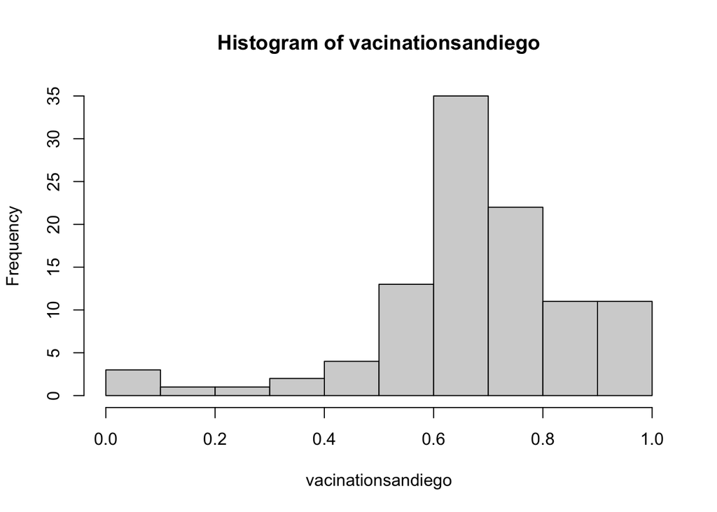

```r
library(ggplot2)

hist(vacinationsandiego)
```

##Focus on UCSD/La Jolla

UC San Diego resides in the 92037 ZIP code area and is listed with an age 5+ population size of 36,144.

```r
ucsd <- filter(sd, zip_code_tabulation_area=="92037")
ucsd[1,]$age5_plus_population
```

```
## [1] 36144
```

> Q15. Using ggplot make a graph of the vaccination rate time course for the 92037 ZIP code area:

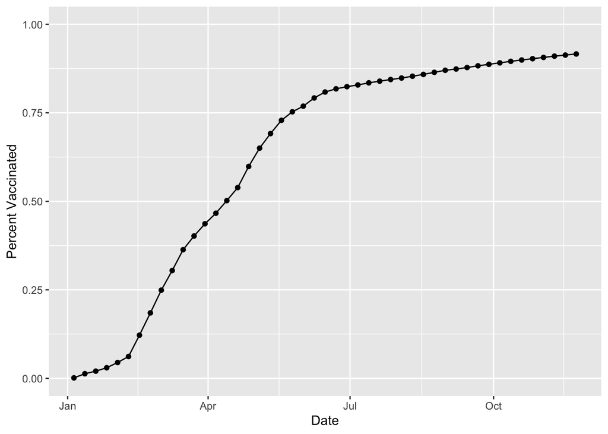

```r
ggplot(ucsd) +
  aes(ucsd$as_of_date,
      ucsd$percent_of_population_fully_vaccinated) +
  geom_point() +
  geom_line(group=1) +
  ylim(c(0,1)) +
  labs(x="Date", y="Percent Vaccinated")
```

##Comparing 92037 to other similar sized areas?

Let’s return to the full dataset and look across every zip code area with a population at least as large as that of 92037 on as_of_date “2021-11-16”.

```r
# Subset to all CA areas with a population as large as 92037
vax.36 <- filter(vax, age5_plus_population > 36144 &
                as_of_date == "2021-11-16")

head(vax.36)
```

|  | as_of_date | zip_code_tabulation_area | local_health_jurisdiction | county | vaccine_equity_metric_quartile | vem_source | age12_plus_population | age5_plus_population | persons_fully_vaccinated | persons_partially_vaccinated | percent_of_population_fully_vaccinated | percent_of_population_partially_vaccinated | percent_of_population_with_1_plus_dose | redacted |
| --- | --- | --- | --- | --- | --- | --- | --- | --- | --- | --- | --- | --- | --- | --- |
| 1 | 2021-11-16 | 92020 | San Diego | San Diego | 2 | Healthy Places Index Score | 49284.5 | 54991 | 35128 | 5161 | 0.638795 | 0.093852 | 0.732647 | No |
| 2 | 2021-11-16 | 92563 | Riverside | Riverside | 3 | Healthy Places Index Score | 55897.8 | 63794 | 36051 | 4224 | 0.565116 | 0.066213 | 0.631329 | No |
| 3 | 2021-11-16 | 92806 | Orange | Orange | 2 | Healthy Places Index Score | 33050.9 | 36739 | 24810 | 2355 | 0.675304 | 0.064101 | 0.739405 | No |
| 4 | 2021-11-16 | 93291 | Tulare | Tulare | 1 | Healthy Places Index Score | 46879.7 | 54254 | 27936 | 4012 | 0.514911 | 0.073948 | 0.588859 | No |
| 5 | 2021-11-16 | 92335 | San Bernardino | San Bernardino | 1 | Healthy Places Index Score | 79670.3 | 91867 | 49820 | 5970 | 0.542306 | 0.064985 | 0.607291 | No |
| 6 | 2021-11-16 | 92618 | Orange | Orange | 4 | Healthy Places Index Score | 40348.0 | 44304 | 39695 | 3936 | 0.895969 | 0.088841 | 0.984810 | No |

> Q16. Calculate the mean “Percent of Population Fully Vaccinated” for ZIP code areas with a population as large as 92037 (La Jolla) as_of_date “2021-11-16”. Add this as a straight horizontal line to your plot from above with the geom_hline() function?

```r
sd.mean<-mean(vax.36$percent_of_population_fully_vaccinated)
```

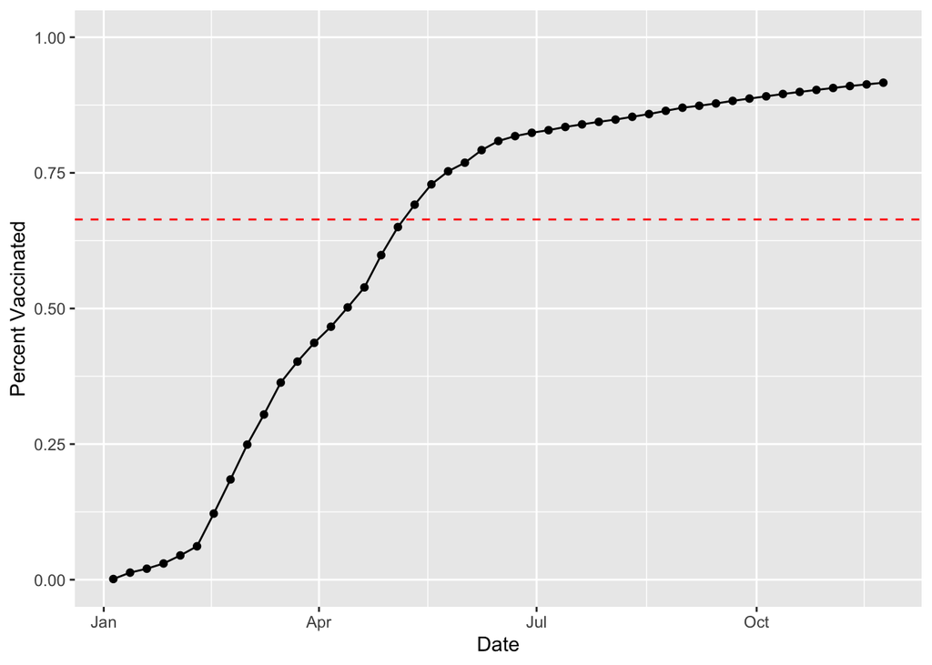

```r
ggplot(ucsd) +
  aes(ucsd$as_of_date,
      ucsd$percent_of_population_fully_vaccinated) +
  geom_point() +
  geom_line(group=1) +
  ylim(c(0,1)) +
  labs(x="Date", y="Percent Vaccinated")+
  geom_hline(aes(yintercept=0.6640413),color="red", lty=2)
```

> Q17. What is the 6 number summary (Min, 1st Qu., Median, Mean, 3rd Qu., and Max) of the “Percent of Population Fully Vaccinated” values for ZIP code areas with a population as large as 92037 (La Jolla) as_of_date “2021-11-16”?

```r
summary(vax.36$percent_of_population_fully_vaccinated)
```

```
##    Min. 1st Qu.  Median    Mean 3rd Qu.    Max.
##  0.3529  0.5905  0.6662  0.6640  0.7298  1.0000
```

> Q18. Using ggplot generate a histogram of this data.

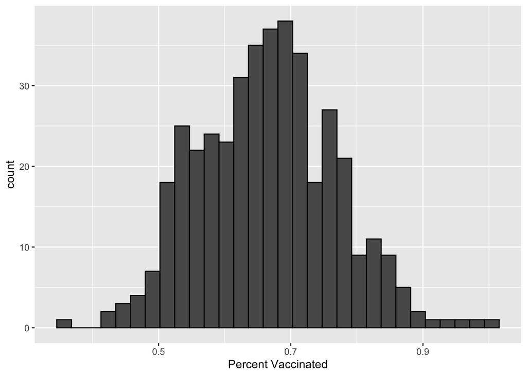

```r
library(ggplot2)
p<-ggplot(vax.36, aes(x=vax.36$percent_of_population_fully_vaccinated)) +
  geom_histogram(color="black") +
  labs(x="Percent Vaccinated")
p
```

> Q19. Is the 92109 and 92040 ZIP code areas above or below the average value you calculated for all these above?

```r
vax %>% filter(as_of_date == "2021-11-16") %>%
  filter(zip_code_tabulation_area=="92040") %>%
  select(percent_of_population_fully_vaccinated)
```

| percent_of_population_fully_vaccinated |
| --- |
| 0.521047 |

> Q20. Finally make a time course plot of vaccination progress for all areas in the full dataset with a age5_plus_population > 36144.

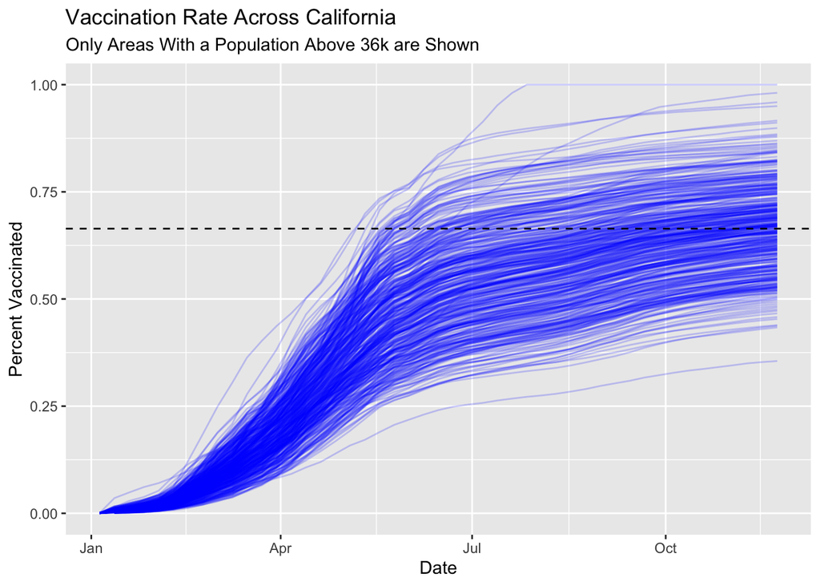

```r
vax.36.all <- filter(vax, age5_plus_population > 36000)


ggplot(vax.36.all) +
  aes(as_of_date,
      percent_of_population_fully_vaccinated,
      group=zip_code_tabulation_area) +
  geom_line(alpha=0.2, color="blue") +
  ylim(c(0,1)) +
  labs(x="Date", y= "Percent Vaccinated",
       title="Vaccination Rate Across California",
       subtitle="Only Areas With a Population Above 36k are Shown") +
  geom_hline(yintercept=0.6640413 , linetype=2)
```

> Q21. How do you feel about traveling for Thanksgiving and meeting for in-person class next Week?

I am vaccinated and tested negative for covid so I’m excited to see my family